# 14. API Iteration Examples

## Wikipedia Page Views Again

Let’s grab the Wikipedia page views data that we worked with in the previous classes. Again, we will start with defining a base URL using the protocol, authority, path, and query parameters.

```r
url_base <- modify_url(
  "https://en.wikipedia.org/w/api.php",
  query = list(action = "query", format = "json", prop = "pageviews")
)
```

To fetch a particular page, all we need to do is add an additional parameter called titles that contains the page title you want to grab.

```r
url_str <- modify_url(url_base, query = list(titles = "apple"))
res <- dsst_cache_get(url_str, cache_dir = "cache")
obj <- content(res, type = "application/json")
```

And as before, we can turn this into a rectangular data set by parsing the list `obj`.

```r
dt <- tibble(
  page = obj$query$pages[[1]]$title,
  date = ymd(names(obj$query$pages[[1]]$pageviews)),
  views = map_int(obj$query$pages[[1]]$pageviews, ~ dsst_null_to_na(.x)),
)
dt
```

```
## # A tibble: 60 × 3
##    page  date       views
##    <chr> <date>     <int>
##  1 Apple 2022-10-31  3839
##  2 Apple 2022-11-01  3870
##  3 Apple 2022-11-02  3982
##  4 Apple 2022-11-03  3954
##  5 Apple 2022-11-04  3903
##  6 Apple 2022-11-05  3265
##  7 Apple 2022-11-06  3481
##  8 Apple 2022-11-07  4081
##  9 Apple 2022-11-08  4082
## 10 Apple 2022-11-09  4109
## # … with 50 more rows
```

Now, let’s try to cycle through all of the pages in the `food` data set. We will build up to this using the techniques you should have read in the R4DS text. **But note that you only actually need the final bit of code.**

To cycle through the foods in the data, we can write for loop like this, printing each food item in every step:

```r
food <- read_csv("../data/food.csv")

for (i in seq_along(food$item))
{
  print(food$item[i])
}
```

```
## [1] "Apple"
## [1] "Asparagus"
## [1] "Avocado"
## [1] "Banana"
## [1] "Chickpea"
## [1] "String Bean"
## [1] "Beef"
## [1] "Bell Pepper"
## [1] "Crab"
## [1] "Broccoli"
## [1] "Cabbage"
## [1] "Cantaloupe"
## [1] "Carrot"
## [1] "Catfish"
## [1] "Cauliflower"
```

[output cut: 46 more lines]

We can actually do something with each entry by creating an output object and assigning something to it. Here, let’s just fill in the list with the food names.

```r
output <- vector("list", nrow(food))

for (i in seq_along(food$item))
{
  output[[i]] <- food$item[i]
}

head(output) # just to see the first few results
```

```
## [[1]]
## [1] "Apple"
##
## [[2]]
## [1] "Asparagus"
##
## [[3]]
## [1] "Avocado"
##
## [[4]]
## [1] "Banana"
##
## [[5]]
## [1] "Chickpea"
##
## [[6]]
## [1] "String Bean"
```

Now, let’s skip ahead by putting the code we had above for the apple page into the for loop structure here.

```r
output <- vector("list", nrow(food))

for (i in seq_along(food$item))
{
  url_str <- modify_url(url_base, query = list(titles = food$wiki[i]))
  res <- dsst_cache_get(url_str, cache_dir = "cache")

  stop_for_status(res)

  obj <- content(res, type = "application/json")
  output[[i]] <- tibble(
    page = obj$query$pages[[1]]$title,
    date = ymd(names(obj$query$pages[[1]]$pageviews)),
    views = map_int(obj$query$pages[[1]]$pageviews, ~ dsst_null_to_na(.x)),
    wiki = food$wiki[i]
  )
}

output <- bind_rows(output)
output
```

```
## # A tibble: 3,660 × 4
##    page  date       views wiki
##    <chr> <date>     <int> <chr>
##  1 Apple 2022-10-31  3839 apple
##  2 Apple 2022-11-01  3870 apple
##  3 Apple 2022-11-02  3982 apple
##  4 Apple 2022-11-03  3954 apple
##  5 Apple 2022-11-04  3903 apple
##  6 Apple 2022-11-05  3265 apple
##  7 Apple 2022-11-06  3481 apple
##  8 Apple 2022-11-07  4081 apple
##  9 Apple 2022-11-08  4082 apple
## 10 Apple 2022-11-09  4109 apple
## # … with 3,650 more rows
```

And now we can work directly with the data using the visualization and data manipulation techniques we have learned in the previous weeks.

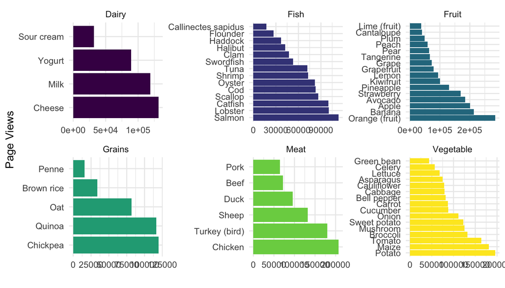

```r
output %>%
  filter(!is.na(views)) %>%
  group_by(page, wiki) %>%
  summarize(total_views = sum(views)) %>%
  inner_join(food, by = "wiki") %>%
  ungroup() %>%
  arrange(desc(total_views)) %>%
  mutate(page = fct_inorder(page)) %>%
  mutate(food_group = stri_trans_totitle(food_group)) %>%
  ggplot(aes(total_views, page)) +
    geom_col(aes(fill = food_group), show.legend = FALSE) +
    scale_fill_viridis_d() +
    facet_wrap(~food_group, scales = "free") +
    labs(x = "", y = "Page Views")
```

## Continuation over an API

As a final example here, let’s see another common API pattern using an API provided by the Library of Congress. We start by creating a base URL:

```r
url_base <- modify_url(
  "https://www.loc.gov/collections/fsa-owi-color-photographs",
  query = list(fo = "json", c = "150")
)
```

Making a request on the base API returns the first 150 results.

```r
res <- dsst_cache_get(url_base, cache_dir = "cache")
obj <- content(res, type = "application/json")
```

Which we can parse using some map functions:

```r
df <- tibble(
  contributor =  map_chr(obj$results, ~ .x$contributor[[1]] ),
  title = map_chr(obj$results, ~ .x$title),
  year = map_chr(obj$results, ~ .x$date),
  state = map_chr(obj$results, ~ dsst_null_to_na(.x$location_state[[1]])),
  city = map_chr(obj$results, ~ dsst_null_to_na(.x$location_city[[1]]))
)
df
```

```
## # A tibble: 150 × 5
##    contributor          title                              year  state city
##    <chr>                <chr>                              <chr> <chr> <chr>
##  1 delano, jack         Commuters, who have just come off… 1939  mass… lowe…
##  2 delano, jack         Railroad cars and factory buildin… 1939  mass… lawr…
##  3 wolcott, marion post Copper mining and sulfuric acid p… 1939  tenn… copp…
##  4 delano, jack         Going to town on Saturday afterno… 1939  geor… <NA>
##  5 wolcott, marion post Copper mining and sulfuric acid p… 1939  tenn… copp…
##  6 wolcott, marion post A train bringing copper ore out o… 1939  tenn… duck…
##  7 wolcott, marion post Copper mining and sulfuric acid p… 1939  tenn… copp…
##  8 wolcott, marion post Southern U.S., Mississippi?        1939  miss… <NA>
##  9 wolcott, marion post Negroes fishing in creek near cot… 1939  miss… belz…
## 10 wolcott, marion post Negroes fishing in creek near cot… 1939  miss… belz…
## # … with 140 more rows
```

The results contain another field called pagination, which has a key called “next” (a reserved word in R, so you need the quotes). It tells us the URL needed to grab the next 150 results:

```r
obj$pagination$"next"
```

```
## [1] "https://www.loc.gov/collections/fsa-owi-color-photographs/?c=150&fo=json&sp=2"
```

And, we can directly call this URL to get the next page:

```r
url_next <- obj$pagination$"next"
res <- dsst_cache_get(url_next, cache_dir = "cache")
obj <- content(res, type = "application/json")
```

Which in turn has another next field with the next set of results:

```r
obj$pagination$"next"
```

```
## [1] "https://www.loc.gov/collections/fsa-owi-color-photographs/?c=150&fo=json&sp=3"
```

In this example, we can easily see the pattern that the query parameter “sp” contains the page number. However, often this is not the case you need to use the next URL field, so let’s do that here.

We want to cycle through the pages until the next field is missing, which requires a little bit more programming:

```r
# create an empty list to store the output in
output <- list()

# set the starting url
url_str <- url_base

# loop through the data until the "next" string is NULL (that means we have hit
# the end of the data)
while (!is.null(url_str))
{
  # grab the next page of data
  res <- dsst_cache_get(url_str, cache_dir = "cache")
  stop_for_status(res)
  obj <- content(res, type = "application/json")

  # parse the data
  df <- tibble(
    contributor = map_chr(obj$results, ~ dsst_null_to_na(.x$contributor[[1]])),
    title = map_chr(obj$results, ~ .x$title),
    year = map_chr(obj$results, ~ dsst_null_to_na(.x$date)),
    state = map_chr(obj$results, ~ dsst_null_to_na(.x$location_state[[1]])),
    city = map_chr(obj$results, ~ dsst_null_to_na(.x$location_city[[1]]))
  )

  # save the results by appending to the output list
  output <- c(output, list(df))

  # set the next page's URL; will be null at the end
  url_str <- obj$pagination$"next"
}

output <- bind_rows(output)
output
```

```
## # A tibble: 1,623 × 5
##    contributor          title                              year  state city
##    <chr>                <chr>                              <chr> <chr> <chr>
##  1 delano, jack         Commuters, who have just come off… 1939  mass… lowe…
##  2 delano, jack         Railroad cars and factory buildin… 1939  mass… lawr…
##  3 wolcott, marion post Copper mining and sulfuric acid p… 1939  tenn… copp…
##  4 delano, jack         Going to town on Saturday afterno… 1939  geor… <NA>
##  5 wolcott, marion post Copper mining and sulfuric acid p… 1939  tenn… copp…
##  6 wolcott, marion post A train bringing copper ore out o… 1939  tenn… duck…
##  7 wolcott, marion post Copper mining and sulfuric acid p… 1939  tenn… copp…
##  8 wolcott, marion post Southern U.S., Mississippi?        1939  miss… <NA>
##  9 wolcott, marion post Negroes fishing in creek near cot… 1939  miss… belz…
## 10 wolcott, marion post Negroes fishing in creek near cot… 1939  miss… belz…
## # … with 1,613 more rows
```

And just for fun, let’s create a plot of the output:

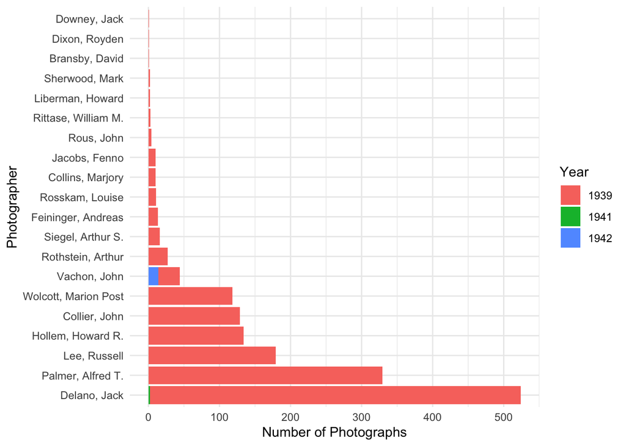

```r
output %>%
  group_by(contributor, year) %>%
  summarize(n = n()) %>%
  ungroup() %>%
  arrange(desc(n)) %>%
  filter(!is.na(contributor)) %>%
  mutate(contributor = stri_trans_totitle(contributor)) %>%
  mutate(contributor = fct_inorder(contributor)) %>%
  ggplot(aes(n, contributor)) +
    geom_col(aes(fill = year)) +
    labs(x = "Number of Photographs", y = "Photographer", fill = "Year")
```